## Preamble

This report will examine the delays in public transport in the city of Zurich, Switzerland, based on data collected in November 2016. The data, found at https://www.openml.org/d/40753, contains the time difference (delay) between scheduled departure and actual departure of each public transport vehicle - bus, tram or trolley - for the duration which this data concerns.

The data will be read from its location on the OpenML website and then pre-processed before being explored further with visualisations including box plots and density plots. Then using the tools in the Scikit learn module, predictive models will be created and tested. This will enable us to create predictions for whether the bus, tram or trolley will be significantly delayed or not.

1. Data Pre-processing
   - Read data and gain an overview of it
   - Check for irrelevant or redundant features
   - Check for unusual values, irregular cardinality, outliers and missing values and deal with them as appropriately
   - Numerically encode categorical features
   - Place features in correct order, sample, create separate arrays for target and descriptive features and scale descriptors
2. Data Exploration and Visualisation
   - Delays by vehicle type
3. Predictive modelling
   - k-Nearest Neighbours
   - Naive Bayes
   - Decition Tree
4. Discussion
5. Conclusion
6. References

## Data Pre-processing

```python
# Load packages and suppress warnings
import numpy as np
import pandas as pd
import warnings
warnings.filterwarnings('ignore')
np.random.seed(200)

# Require pandas data frames to display all columns
pd.set_option('display.max_columns',None)
```

#### Read data and gain an overview of it

```python
# Load data
import requests, io
link='https://www.openml.org/data/get_csv/5698591/file62a9329beed2.arff'
content=requests.get(link).content
zurich_delays=pd.read_csv(io.StringIO(content.decode('utf-8')))

# Check data uploaded correctly and review it
print("Number of rows: " + str(zurich_delays.shape[0]))
print("Number of columns: " + str(zurich_delays.shape[1]))
zurich_delays.sample(n=5, random_state=200)
```

```
Number of rows: 5465575
Number of columns: 15
```

|  | delay | vehicle_type | line_number | direction | stop_id | weekday | time | temp | windspeed_max | windspeed_avg | precipitation | dew_point | humidity | hour | dayminute |
| --- | --- | --- | --- | --- | --- | --- | --- | --- | --- | --- | --- | --- | --- | --- | --- |
| 4645164 | 125 | Bus | ? | 1 | 5616 | 3 | 2016-11-01 12:59:59 | 13.1 | 1.7 | 1.1 | 0.0 | 7.6 | 69 | 12 | 779 |
| 5074475 | 46 | Bus | ? | 1 | 5655 | 5 | 2016-11-03 22:30:00 | 4.5 | 2.6 | 1.8 | 0.0 | 1.8 | 83 | 22 | 1350 |
| 4891712 | -17 | Tram | 5 | 2 | 10652 | 5 | 2016-11-03 16:20:00 | 9.9 | 5.7 | 4.0 | 0.0 | 3.0 | 62 | 16 | 980 |
| 303962 | 38 | Bus | 80 | 1 | 10961 | 2 | 2016-11-14 21:10:00 | 2.3 | 4.0 | 2.4 | 0.0 | -0.2 | 84 | 21 | 1270 |
| 96536 | 16 | Bus | 66 | 2 | 10923 | 1 | 2016-11-13 12:59:59 | 5.1 | 3.0 | 1.5 | 0.0 | 1.5 | 77 | 12 | 779 |

```python
# Check data types
print(zurich_delays.dtypes)
```

```
delay              int64
vehicle_type      object
line_number       object
direction          int64
stop_id            int64
weekday            int64
time              object
temp             float64
windspeed_max    float64
windspeed_avg    float64
precipitation    float64
dew_point        float64
humidity           int64
hour               int64
dayminute          int64
dtype: object
```

#### Check for irrelevant or redundant features

There are no incident identification labels that need removing. There are, though, identification numbers for lines and stops. The line number is a label for the line, or route, taken by the bus, tram or trolley. This is a useful feature for learning as it is necessary to distinguish between different lines. Some may be more prone to traffic congestion, and therefore long delays may be more likely on such lines. It should not be removed but kept as a categorical feature. Being a nominal categorical feature, it should be one-hot encoded. The stop ID (stop_id) could be treated similarily, though there are likely to be very many stops leading to an extremely large number of features created by one-hot encoding.

```python
# Check number of stop IDs
zurich_delays['stop_id'].nunique()
```

```
1530
```

It would be better if this number was smaller to reduce the problem of high dimensionality. However, feature selection will ensure only the most important features are used. If it turns out that the rate of significant delays at a certain stop is no different to the average, then the feature pertaining to that stop is unlikely to be included in the model.

The hour is redundant as the hour is already included in the 'dayminute' variable. Currently hours denotes the hours after midnight. For example, if hours equals 12 than the incident was at 12 hours after midnight (i.e. noon). But this would also be given as 720 (12 * 60 minutes = 720 minutes), plus minutes after the hour, in the 'dayminute' feature.

```python
zurich_delays.drop(columns='hour', inplace=True)
```

The features of interest concerning day and time are the day of the week and the time of the day which are captured by 'weekday' and 'dayminute' respectively. The date - the 'time' feature - may also be useful for capturing seasonal variation.

```python
zurich_delays['time'].unique()
```

```
array(['2016-11-13 05:00:00', '2016-11-13 05:10:00',
       '2016-11-13 05:19:59', ..., '2016-11-05 04:40:00',
       '2016-11-05 04:30:00', '2016-11-06 01:20:00'], dtype=object)
```

The observations appear to be all from November 2016. Hence no seasonal variation will be captured by this feature. It can be removed.

```python
zurich_delays.drop(columns='time', inplace=True)
```

```python
zurich_delays['precipitation'].unique()
```

```
array([0. , 0.4, 0.1, 0.6, 0.2, 0.5, 0.3, 0.9, 0.7, 0.8, 1. , 1.2, 1.8,
       1.1, 1.6])
```

There are other values for precipitation so this feature is not constant. So it should not be removed.

#### Check for unusual values, irregular cardinality, outliers and missing values and deal with them as appropriately

```python
# Clean categorical features
categorical_cols_mask=zurich_delays.dtypes==object
categorical_cols=zurich_delays.columns[categorical_cols_mask]

# Look for typos, irregular cardinality, missing values, white space and any other issue in the cateogorical features.
for col in categorical_cols:
    print("Feature: " + col)
    print("Unique values:")
    print(zurich_delays[col].unique())
    print()
```

```
Feature: vehicle_type
Unique values:
['Tram' 'Trolley' 'Bus']

Feature: line_number
Unique values:
[2 3 4 5 7 6 8 9 10 11 12 13 15 14 17 31 32 33 35 34 62 61 46 38 40 37 66
 67 69 64 70 72 75 78 77 80 79 94 184 185 165 89 161 301 302 303 304 308
 311 305 306 '304' '311' '325' '743' '308' '751' '?' '912' '2' '910' '3'
 '4' '5' '7' '6' '8' '9' '10' '11' '61' '34' '38' '46' '40' '37' '62' '66'
 '64' '67' '69' '70' '72' '75' '78' '77' '76' '79' '80' '89' '94' '165'
 '162' '163' '184' '185' '301' '161' '302' '303' '306' '305' '309' '314'
 '744' '745' '916' '918' '919' '753' 76 162 163 916 753 918 919 '35' '12'
 '32' 912 '33']
```

Irregular cardinality exists in the line_number feature. Some numbers are in single quotation marks, while others are not. Therefore these quotation marks should be removed.

```python
zurich_delays['line_number'].replace(['304', '311', '325', '743', '308', '751', '912', '2',
       '910', '3', '4', '5', '7', '6', '8', '9', '10', '11', '61', '34',
       '38', '46', '40', '37', '62', '66', '64', '67', '69', '70', '72',
       '75', '78', '77', '76', '79', '80', '89', '94', '165', '162',
       '163', '184', '185', '301', '161', '302', '303', '306', '305',
       '309', '314', '744', '745', '916', '918', '919', '753', '35', '12', '32', '33'],
                                     [304, 311, 325, 743, 308, 751, 912, 2,
                                      910, 3, 4, 5, 7, 6, 8, 9, 10, 11, 61, 34, 38, 46,
                                      40, 37, 62, 66, 64, 67, 69, 70, 72, 75, 78, 77, 76,
                                      79, 80, 89, 94, 165, 162, 163, 184, 185, 301, 161,
                                      302, 303, 306, 305, 309, 314, 744, 745, 916, 918, 919, 753, 35, 12, 32, 33], inplace=True)
```

```python
#Check unique entries for line_number now.
zurich_delays['line_number'].unique()
```

```
array([2, 3, 4, 5, 7, 6, 8, 9, 10, 11, 12, 13, 15, 14, 17, 31, 32, 33, 35,
       34, 62, 61, 46, 38, 40, 37, 66, 67, 69, 64, 70, 72, 75, 78, 77, 80,
       79, 94, 184, 185, 165, 89, 161, 301, 302, 303, 304, 308, 311, 305,
       306, 325, 743, 751, '?', 912, 910, 76, 162, 163, 309, 314, 744,
       745, 916, 918, 919, 753], dtype=object)
```

We will now look for and deal with any missing values.

```python
# Check for missing values
zurich_delays.isna().sum()
```

```
delay            0
vehicle_type     0
line_number      0
direction        0
stop_id          0
weekday          0
temp             0
windspeed_max    0
windspeed_avg    0
precipitation    0
dew_point        0
humidity         0
dayminute        0
dtype: int64
```

```python
# While there were no missing values detected  by the above test, there are some '?' entries in the dataset.
# The number of these will be checked.
for col in categorical_cols:
    print(col+str("\ncount of '?':"))
    print(sum(zurich_delays[col]=='?'))
    print()
```

```
vehicle_type
count of '?':
0

line_number
count of '?':
132617
```

There are many '?' entries for line_number. This means the line number was not entered. Imputing, for example, the most frequent line number will introduce bias into the data set. Therefore these observations will be removed.

```python
zurich_delays=zurich_delays[zurich_delays.loc[:,'line_number']!='?']
# Check that all '?' values are removed
print("Number of remaining '?'s: "+str(sum(zurich_delays['line_number']=='?')))
```

```
Number of remaining '?'s: 0
```

#### Numerically encode categorical features

As mentioned earlier, the line number and stop ID need to be one-hot encoded. The vehicle type and weekday are also categorical features that needs to be numerically encoded with one-hot encoding. (The weekday, while a number, denotes a day of the week. One day cannot be considered to be "twice as much" or "three times as much" as another day of the week.)

Furthermore, the direction is another categorical feature. Presuming only two directions, this can be encoded in binary fashion as 1 or 0.

```python
# Check direction feature
zurich_delays['direction'].unique()
```

```
array([1, 2], dtype=int64)
```

As expected the direction is binary. Currently it has values of either 1 or 2. These will be changed to 0 and 1 respectively.

```python
zurich_delays['direction']=np.where(zurich_delays['direction']==1,0,1)
```

In order to one-hot encode the stop_id and weekday features, each will be changed to be of "object" type.

```python
zurich_delays['stop_id']=zurich_delays['stop_id'].astype(object)
zurich_delays['weekday']=zurich_delays['weekday'].astype(object)
```

Now the other four categorical features - vehicle type, line number, week day and stop ID - will be one-hot encoded.

```python
# One-hot encode categorical variables
zurich_delays=pd.get_dummies(zurich_delays)
```

#### Place features in correct order, sample, create separate arrays for target and descriptive features and scale descriptors

The target column is usually placed on the right. We are interested in the delay in the bus, tram or trolley so 'delay' is the target feature. So 'delay' will be placed on the right.

```python
# Put 'delay' column last
zurich_delays=zurich_delays[[col for col in zurich_delays.columns if col not in ['delay']]+['delay']]

# Inspect modified data set
print("Number of rows: " + str(zurich_delays.shape[0]))
print("Number of columns: " + str(zurich_delays.shape[1]))
zurich_delays.sample(n=5, random_state=200)
```

```
Number of rows: 5332958
Number of columns: 1581
```

|  | direction | temp | windspeed_max | windspeed_avg | precipitation | dew_point | humidity | dayminute | vehicle_type_Bus | vehicle_type_Tram | vehicle_type_Trolley | line_number_2 | line_number_3 | line_number_4 | line_number_5 | line_number_6 | line_number_7 | line_number_8 | line_number_9 | line_number_10 | line_number_11 | line_number_12 | line_number_13 | line_number_14 | line_number_15 | line_number_17 | line_number_31 | line_number_32 | line_number_33 | … |
| --- | --- | --- | --- | --- | --- | --- | --- | --- | --- | --- | --- | --- | --- | --- | --- | --- | --- | --- | --- | --- | --- | --- | --- | --- | --- | --- | --- | --- | --- | --- |
| 4732550 | 1 | 7.4 | 2.2 | 1.3 | 0.0 | 6.8 | 96 | 360 | 0 | 1 | 0 | 0 | 0 | 0 | 0 | 0 | 0 | 0 | 0 | 0 | 0 | 0 | 1 | 0 | 0 | 0 | 0 | 0 | 0 | … |
| 3495303 | 1 | 5.1 | 6.9 | 1.9 | 0.0 | 3.9 | 92 | 499 | 0 | 1 | 0 | 0 | 1 | 0 | 0 | 0 | 0 | 0 | 0 | 0 | 0 | 0 | 0 | 0 | 0 | 0 | 0 | 0 | 0 | … |
| 2177421 | 0 | 8.0 | 5.1 | 2.8 | 0.0 | 5.3 | 83 | 570 | 0 | 1 | 0 | 0 | 0 | 0 | 0 | 1 | 0 | 0 | 0 | 0 | 0 | 0 | 0 | 0 | 0 | 0 | 0 | 0 | 0 | … |
| 901864 | 0 | 9.4 | 4.0 | 2.0 | 0.0 | 6.9 | 85 | 450 | 0 | 0 | 1 | 0 | 0 | 0 | 0 | 0 | 0 | 0 | 0 | 0 | 0 | 0 | 0 | 0 | 0 | 0 | 0 | 0 | 0 | … |
| 225228 | 1 | 2.5 | 3.5 | 1.8 | 0.0 | -0.2 | 82 | 689 | 0 | 1 | 0 | 0 | 0 | 0 | 0 | 0 | 0 | 0 | 0 | 0 | 0 | 0 | 0 | 0 | 1 | 0 | 0 | 0 | 0 | … |

The number of observations is extremely large. To make the process more manageable for the computer, a sample of 5000 will be taken to be used henceforth.

```python
#Take a sample of size 5000
zurich_delays_smp=zurich_delays.sample(n=5000,random_state=200)
```

We need to define how late a service has to be in order to be classified as significantly delayed. I will classify all services delayed by more than four minutes (240 seconds) late as significantly delayed. I will create a new variable - which will be the target feature - to indicate whether the departure is significantly delayed or not based on this criterion.

```python
zurich_delays_smp['significantly_delayed']=np.where(zurich_delays_smp['delay']>240,1,0)
```

The descriptive features and the target need to be separated and converted to numpy arrays because the Scikit-learn module which we will use to do predictive modelling is designed to work with numpy arrays not pandas data frames. Once this is done the descriptive features will be scaled, and pre-processing will be complete.

```python
# Separate descriptive features and target and convert to numpy arrays
Data=zurich_delays_smp.drop(columns=['delay','significantly_delayed']).values
target=zurich_delays_smp['significantly_delayed'].values

# Scale descriptive features
from sklearn import preprocessing
Data=preprocessing.MinMaxScaler().fit_transform(Data)
```

Note the 'significantly delayed' feature is the target. The feature 'delay' is not the target nor a descriptive variable so it is not included in the numpy arrays that will be used for predictive modelling. It will, however, be of interest to visualise this delay is affected by the descriptive features.

## Data Exploration and Visualisation

We will now examine the data with visualisations to assist in understanding the relationship between various descriptive features and the delay in a given public transport departure.

```python
import matplotlib.pyplot as plt
%matplotlib inline
%config InlineBackend.figure_format='retina'
plt.style.use("ggplot")
```

Before we look at the relationship between descriptive features and the delay it will be good to gain an understanding of the distribution of the delay.

A histogram is an excellent way to view the distribution of a single variable.

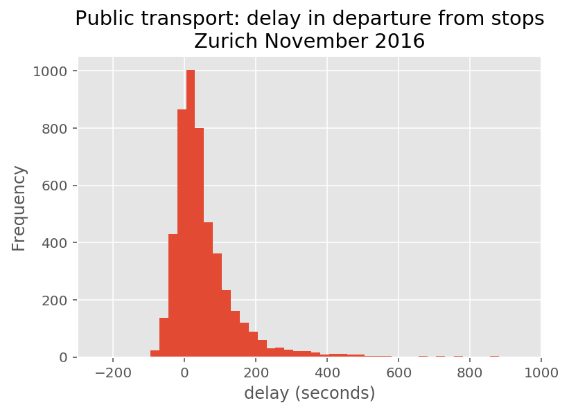

```python
# Create a histogram of delays
zurich_delays_smp['delay'].plot(kind='hist', bins=100)
plt.xlim(-300,1000)
plt.title('Public transport: delay in departure from stops\nZurich November 2016')
plt.xlabel('delay (seconds)')
plt.show()
```

The delays are positively skewed. This makes sense as negative delays indicate that the bus, tram or trolley is early, and it is far more likely for public transport to be very late than very early. If a bus, for example, is running ahead of schedule, the driver can simply pause at a stop until the correct departure time. But if he is running late due to heavy traffic, the traffic and speed limits may not allow him to catch up the lost time.

We should also consider what proportion of public transport departures are significantly delayed. The pie chart below graphically illustrates this proportion.

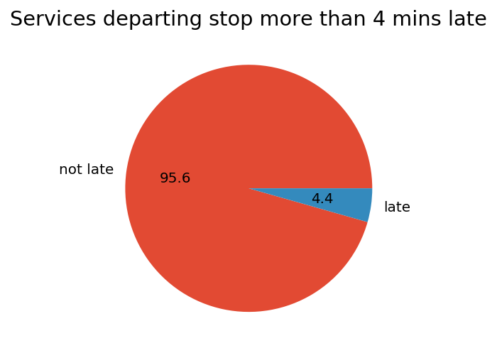

```python
df=zurich_delays_smp[['vehicle_type_Bus']+['vehicle_type_Tram']+['vehicle_type_Trolley']+['weekday_1']+['weekday_2']+['weekday_3']+['weekday_4']+['weekday_5']+['weekday_6']+['weekday_7']+['delay']+['significantly_delayed']]
df['significantly_delayed']=np.where(df['significantly_delayed']==1,'late','not late')
df['significantly_delayed'].value_counts().plot(kind='pie', autopct='%.1f')
plt.ylabel(None)
plt.title('Services departing stop more than 4 mins late')
plt.show()
```

From the pie chart we can see that 4.4% of all arrivals/departures are more than four minutes late.

#### Delays by vehicle type

It will be of interest to see how each mode of public transport - bus, tram or trolley - performs as regards punctuality. Side-by-side boxplots will enable us to compare the punctuality of the three modes of public transport, both in terms of central tendency as well as variation.

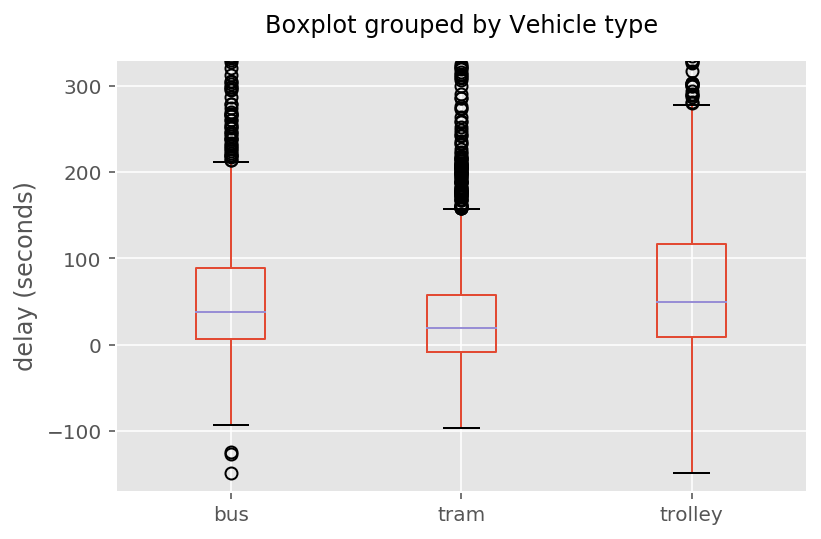

```python
df['Vehicle type']=df['vehicle_type_Tram'].replace(1,'tram')
df['Vehicle type']=np.where(df['vehicle_type_Bus']==1,'bus', df['Vehicle type'])
df['Vehicle type']=np.where(df['vehicle_type_Trolley']==1,'trolley', df['Vehicle type'])
df.boxplot(column='delay', by = 'Vehicle type')
plt.title(None)
plt.xlabel(None)
plt.ylim(-170,330)
plt.ylabel('delay (seconds)')
plt.show()
```

It seems that the trams have the best performance with the lowest median delay and lowest variation in delay also. Buses appear to have a better performance than trolleys with a slightly lower median and also less variation.

Now we will look at each mode of pubic transport individually.

##### Buses

The delays for buses are reflected in the following boxplot and density plot, which will give a sense of the central tendency and spread of the distribution of bus delays.

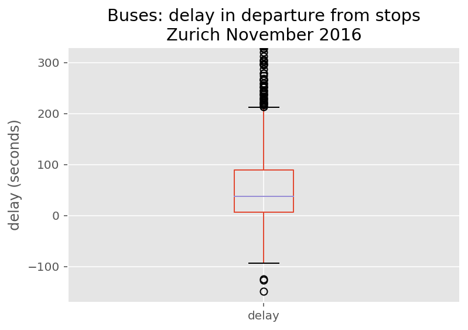

```python
df[df['vehicle_type_Bus']==1].boxplot(column='delay')
plt.title('Buses: delay in departure from stops\nZurich November 2016')
plt.ylim(-170,330)
plt.ylabel('delay (seconds)')
plt.show()
```

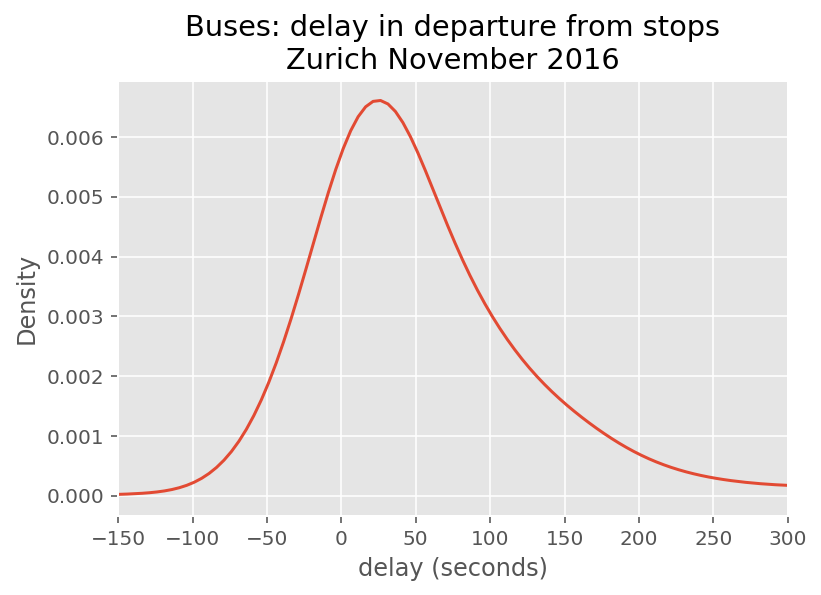

```python
df['delay'][df['vehicle_type_Bus']==1].plot(kind='density')
plt.title('Buses: delay in departure from stops\nZurich November 2016')
plt.xlim(-150,300)
plt.xlabel('delay (seconds)')
plt.show()
```

The above plots show that the majority of buses depart between 0 and 100 seconds after the scheduled time. We can also compare performances across weekdays.

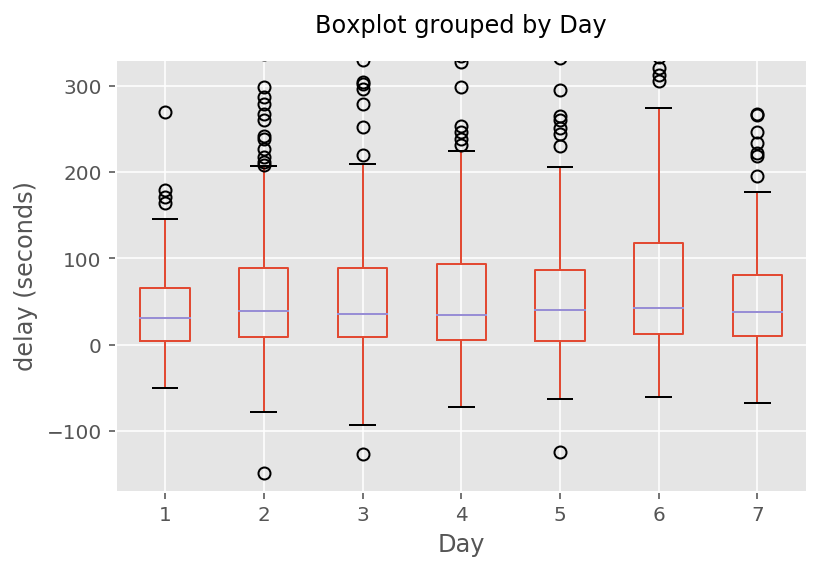

```python
df['Day']=np.where(df['weekday_1']==1,1,0)
df['Day']=np.where(df['weekday_2']==1,2,df['Day'])
df['Day']=np.where(df['weekday_3']==1,3,df['Day'])
df['Day']=np.where(df['weekday_4']==1,4,df['Day'])
df['Day']=np.where(df['weekday_5']==1,5,df['Day'])
df['Day']=np.where(df['weekday_6']==1,6,df['Day'])
df['Day']=np.where(df['weekday_7']==1,7,df['Day'])
df[df['vehicle_type_Bus']==1].boxplot(column='delay', by='Day')
plt.title(None)
plt.ylim(-170,330)
plt.ylabel('delay (seconds)')
plt.show()
```

It appears that there are slightly worse delays on days 2-6.

We can also compare performance on hot days with performance on cold days.

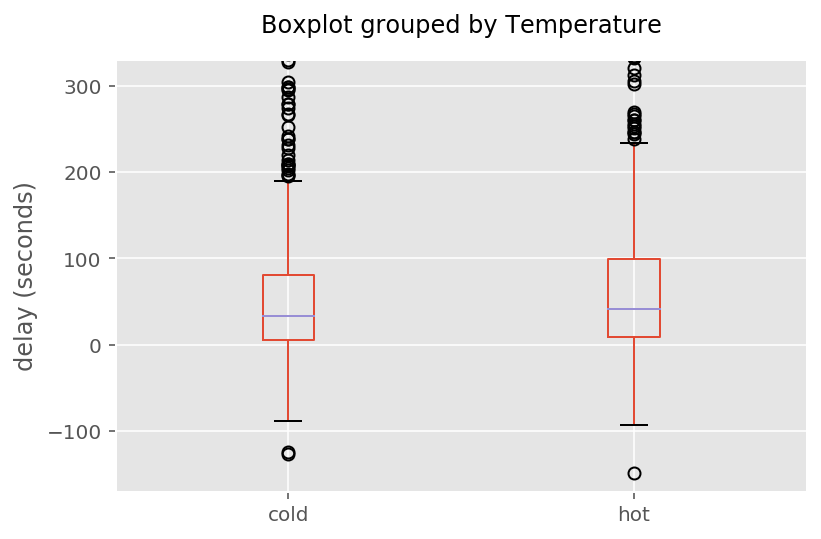

```python
df['Temperature']=np.where(zurich_delays_smp['temp']<np.median(zurich_delays_smp['temp']),'cold','hot')
df[df['vehicle_type_Bus']==1].boxplot(column='delay', by = 'Temperature')
plt.title(None)
plt.xlabel(None)
plt.ylabel('delay (seconds)')
plt.ylim(-170, 330)
plt.show()
```

It seems that buses travel slightly closer to schedule on cold days than hot days, but the difference is very small. Perhaps less people go out on cold days and so there are less passengers, making it easier for drivers to stay on time. As the difference appears very small, some more analysis is worthwhile to judge whether it is significant.

```python
mu1=np.round(np.mean(df['delay'][(df['vehicle_type_Bus']==1)&(df['Temperature']=='cold')]),3)
print("The mean of the bus delays in cold weather is "+str(mu1)+".")
mu2=np.round(np.mean(df['delay'][(df['vehicle_type_Bus']==1)&(df['Temperature']=='hot')]),3)
print("The mean of the bus delays in hot weather is "+str(mu2)+".")
print("The difference in means is "+str(np.round(max(mu1,mu2)-min(mu1,mu2),3))+".")
sdBus=np.round(np.sqrt(np.var(df['delay'][df['vehicle_type_Bus']==1])),3)
print("The standard deviation of the bus delays is "+str(sdBus)+".")
```

```
The mean of the bus delays in cold weather is 56.981.
The mean of the bus delays in hot weather is 75.052.
The difference in means is 18.071.
The standard deviation of the bus delays is 128.268.
```

The difference in much less than one standard deviation. So the difference cannot be claimed to be significant.

We should consider also the overall proportion of buses departing significantly late from stops. The pie chart below illustrates this proportion in an easy to understand way.

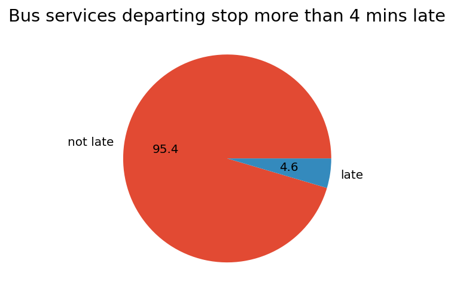

```python
df['significantly_delayed'][df['vehicle_type_Bus']==1].value_counts().plot(kind='pie', autopct='%.1f')
plt.ylabel(None)
plt.title('Bus services departing stop more than 4 mins late')
plt.show()
```

It can be seen that the proportion departing more than four minutes late is very similar to the overall proportion for all three modes of transport.

##### Trams

Let us now consider how trams fared in regards to departure time. Again, a boxplot and density plot help visualise the distribution of depature times.

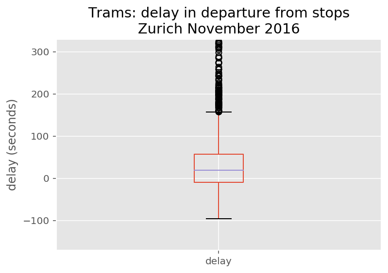

```python
df[df['vehicle_type_Tram']==1].boxplot(column='delay')
plt.title('Trams: delay in departure from stops\nZurich November 2016')
plt.ylim(-170,330)
plt.ylabel('delay (seconds)')
plt.show()
```

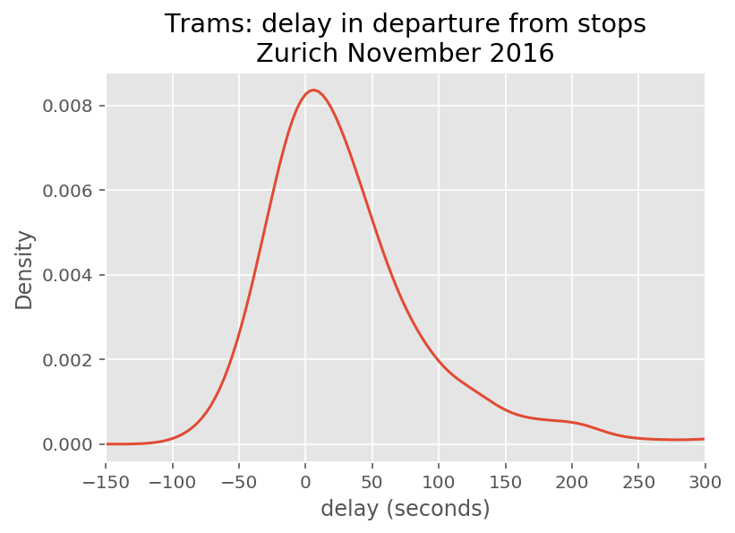

```python
df['delay'][df['vehicle_type_Tram']==1].plot(kind='density')
plt.title('Trams: delay in departure from stops\nZurich November 2016')
plt.xlim(-150,300)
plt.xlabel('delay (seconds)')
plt.show()
```

From the boxplot it can be seen that trams are quite punctual, with the upper quartile at about 60 seconds, which would indicate that only one quarter are more than a minute late.

Now we will consider the performance of trams across each day of the week.

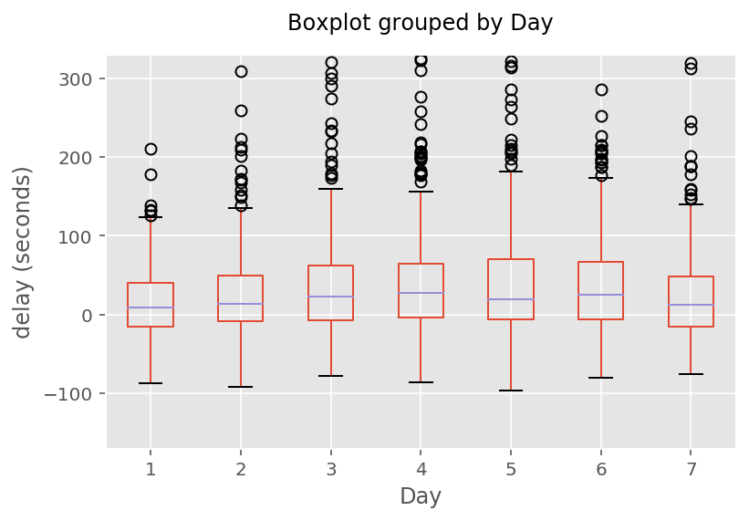

```python
df[df['vehicle_type_Tram']==1].boxplot(column='delay', by='Day')
plt.title(None)
plt.ylim(-170,330)
plt.ylabel('delay (seconds)')
plt.show()
```

It appears that there are slightly worse delays on days 3-6.

We can also compare tram performance on cold and hot days.

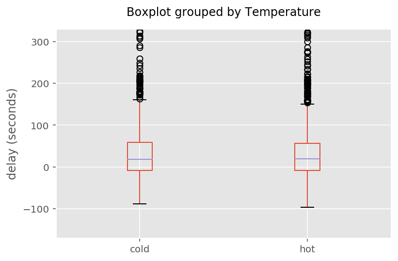

```python
df[df['vehicle_type_Tram']==1].boxplot(column='delay', by = 'Temperature')
plt.title(None)
plt.xlabel(None)
plt.ylabel('delay (seconds)')
plt.ylim(-170, 330)
plt.show()
```

Judging by this boxplot here is little difference between tram performance on cold and hot days.

Now we shal consider the overall proportion of trams arriving more than four minutes late.

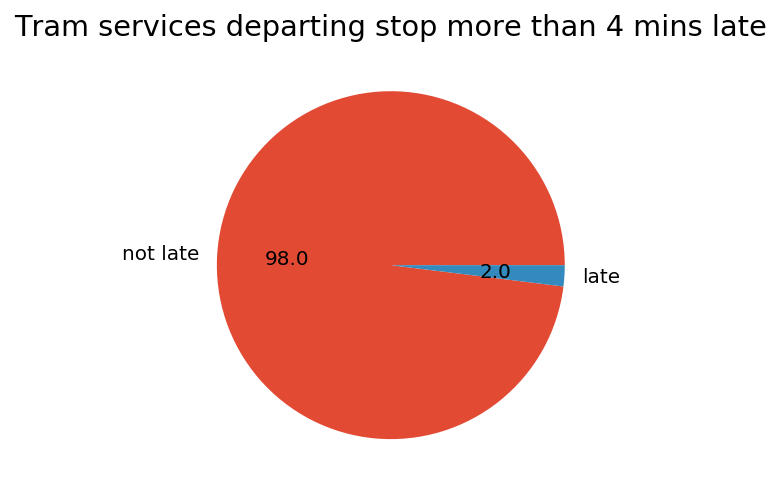

```python
df['significantly_delayed'][df['vehicle_type_Tram']==1].value_counts().plot(kind='pie', autopct='%.1f')
plt.ylabel(None)
plt.title('Tram services departing stop more than 4 mins late')
plt.show()
```

Consistent with our earlier observation that trams performed best, the pie chart above shows that the proportion of trams being significantly delayed is lower - only 2.0% - than the overall proportion for all vehicle types.

##### Trolleys

We will now consider the delays in trolley departures. Again a box plot and density plot indicates the typical delay and the variation in delay.

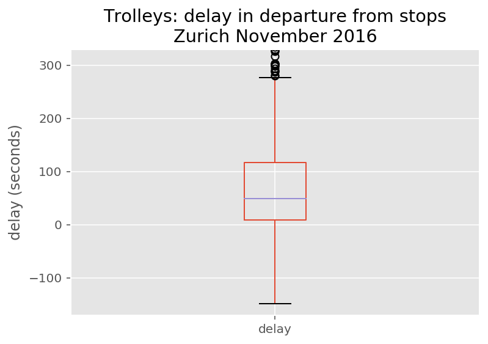

```python
df[df['vehicle_type_Trolley']==1].boxplot(column='delay')
plt.title('Trolleys: delay in departure from stops\nZurich November 2016')
plt.ylim(-170,330)
plt.ylabel('delay (seconds)')
plt.show()
```

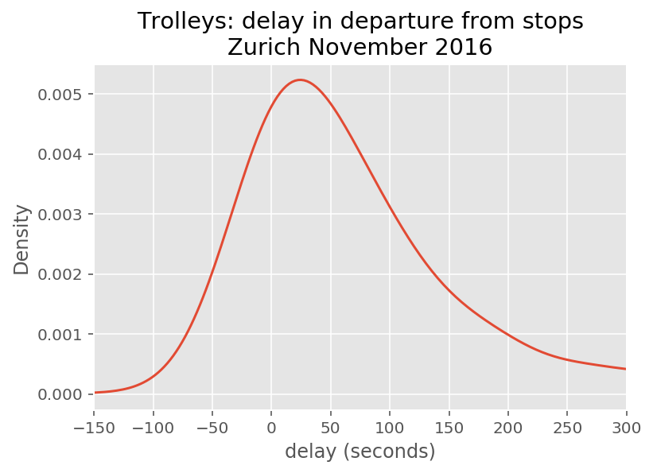

```python
df['delay'][df['vehicle_type_Trolley']==1].plot(kind='density')
plt.title('Trolleys: delay in departure from stops\nZurich November 2016')
plt.xlim(-150,300)
plt.xlabel('delay (seconds)')
plt.show()
```

The tail on the right of the density plot decreases more slowly than that for trams and buses, indicating a larger proportion of late trolleys. The boxplot also shows that the upper quartile is above 100 seconds, which indicates that more than one quarter of trolleys are late by more than 100 seconds.

Again, we will consider the relative performance across each day of the week.

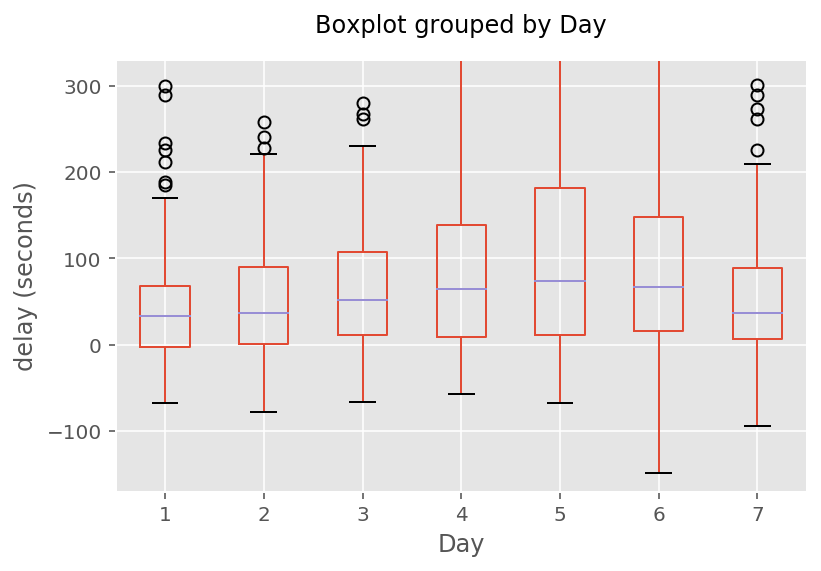

```python
df[df['vehicle_type_Trolley']==1].boxplot(column='delay', by='Day')
plt.title(None)
plt.ylim(-170,330)
plt.ylabel('delay (seconds)')
plt.show()
```

The delays are again longer on days 3-6.

The performance of trolleys in cooler and hotter weather is considered.

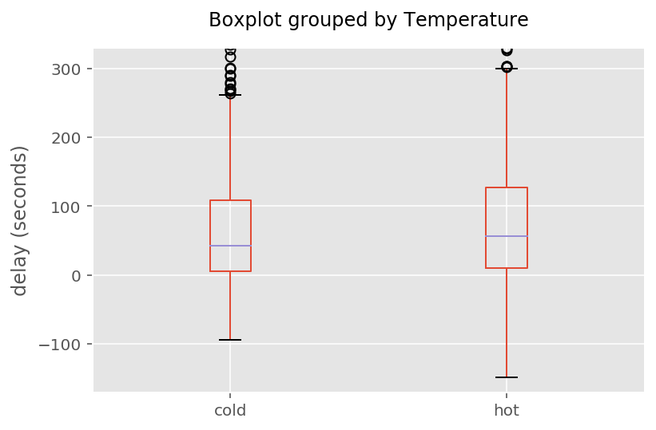

```python
df[df['vehicle_type_Trolley']==1].boxplot(column='delay', by = 'Temperature')
plt.title(None)
plt.xlabel(None)
plt.ylabel('delay (seconds)')
plt.ylim(-170, 330)
plt.show()
```

The median departure time is slightly worse on hot days than cold days - the delay being slightly longer. Again it is only a small difference.

The proportion of significantly late trolleys is shown in the pie graph below.

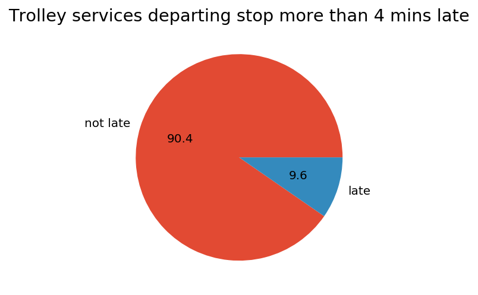

```python
df['significantly_delayed'][df['vehicle_type_Trolley']==1].value_counts().plot(kind='pie', autopct='%.1f')
plt.ylabel(None)
plt.title('Trolley services departing stop more than 4 mins late')
plt.show()
```

The pie charts, in addition to the box plots, indicate that trams performed best, follwed by buses and trolleys were worst performing.

#### Delays by time of day

There are certain times of day, especially in the morning and evening "peak hour" when traffic is likely to be busier and services are more likely to be highly patronised, which can lead to delays. At these times also, we may expect the traffic to be mainly in one direction, namely towards the central business district in the morning, and away from it in the evening. The scatterplot below attempts to identify if these factors are affecting public transport punctuality.

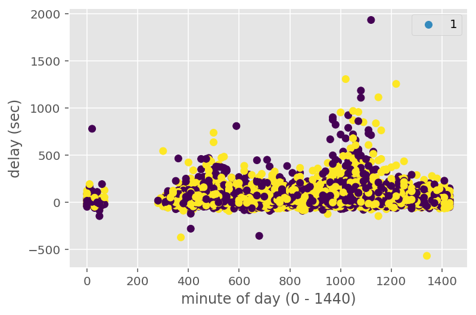

```python
plt.scatter(x=zurich_delays_smp['dayminute'], y=zurich_delays_smp['delay'], c=zurich_delays_smp['direction'])
plt.xlabel('minute of day (0 - 1440)')
plt.ylabel('delay (sec)')
plt.legend(zurich_delays_smp['direction'])
plt.show()
```

There appears to be some longer delays in the late afternoon and evening.

## Predictive Modelling

The affects of the vehicle type, the day of the week, temperature, time of day and direction on the delay in a public transport service at any given stop has been considered. Now these and the other features we have retained - such as stop ID and line number - will be used to create models predicting whether any given public transport departure in Zurich will be significantly delayed or not (using the standard of delays longer than four minutes being "significant delays"). Three models will be created, one with each of the following algorithms: k-nearest neighbours, naive Bayes and decision trees. Finally, these models will be evaluated for performance.

Because it is an important principle of machine learning that algorithms be tested on data used neither for training nor hyper-parameter fine-tuning, the data will be partitioned to create a separate test set.

```python
from sklearn.model_selection import train_test_split
D_train, D_test, t_train, t_test=train_test_split(Data, target, test_size=0.3, stratify=target, shuffle=True, random_state=200)
```

Each of k-nearest neighbours, naive Bayes and decision trees will be used to fit a model for predicting whether a departure will be significantly delayed or not. To evaluate models, a metric for comparing models is required. As this is a classification problem with class imbalance as shown below - only a small portion of the departures are delayed by more than four minutes - the metric used will be the f1 score.

```python
# Show extent of class imbal
zurich_delays_smp['significantly_delayed'].value_counts()
```

```
0    4780
1     220
Name: significantly_delayed, dtype: int64
```

First the k-Nearest Neighbours algorithm will be fitted to predict whether a departure will be significantly delayed or not.

#### k-Nearest Neighbours

Public transport services with similar features such as vehicle type, time of day, day of the week, etc. are more likely to share a similar delay. There may be certain combinations of feature values that are more prevalent in cases where the departure is delayed. Therefore a classifier that predicts a departure as either of two classes, significant delayed or not significantly delayed, base on the class of similar departures, may be a good classifier.

It may be that only some features are important in determining whether a departure is significantly delayed or not. To determine the most important features a random forest classifier will be used to determine the importance of each feature in providing information about the target. Then the features will be ranked in terms of their importance, and the most important 10, 20, 30 and 40 features will be used to classify the departures. By varying the number of neighbours from 1 to 7 and using both Manhattan and Euclidean metrics, as well as varying the number of features included in the model, the best combination can be found. A grid search will fit models for each combination and evaluate the f1 score so that the optimal algorithm hyperparameters and number of features can be found.

```python
# Create a random forest feature selector
# create a class to use Random Forest Importances to select best features for making predictions
# credits to (Feature Ranking, 2019, Hyperparameter Tuning: K-Nearest Neighbors (KNN)) for below (start quote)
from sklearn.ensemble import RandomForestClassifier
from sklearn.base import BaseEstimator, TransformerMixin

class RFIFeatureSelector(BaseEstimator, TransformerMixin):

    # class constructor
    def __init__(self, n_features_=10):
        self.n_features_ = n_features_
        self.fs_indices_ = None

    # override fit function
    def fit(self, X, y):
        model_rfi = RandomForestClassifier(n_estimators=100)
        model_rfi.fit(X,y)
        self.fs_indices_ = np.argsort(model_rfi.feature_importances_)[::-1][0:self.n_features_]
        return self

    # override the transform function
    def transform(self, X, y = None):
        return X[:, self.fs_indices_]
# (end quote)
```

```python
# Perform a grid search to find best number of features and k-nearest neighbours hyperparameters
from sklearn.model_selection import GridSearchCV
from sklearn.pipeline import Pipeline
from sklearn.neighbors import KNeighborsClassifier
from sklearn.model_selection import RepeatedKFold

pipe_KNN=Pipeline([('rfi_fs',RFIFeatureSelector()),
                   ('knn',KNeighborsClassifier())])
cv_method=RepeatedKFold(n_splits=5,n_repeats=2, random_state=200)
params={'rfi_fs__n_features_': [10, 20, 30, 40],
        'knn__n_neighbors': [1, 3, 5, 7],
        'knn__p': [1,2]}
gs_KNN=GridSearchCV(estimator=pipe_KNN,
                    param_grid=params,
                    cv=cv_method,
                    refit=True,
                    scoring='f1',
                    verbose=1,
                    n_jobs=-2
                    )
gs_KNN.fit(D_train, t_train)
```

```
Fitting 10 folds for each of 32 candidates, totalling 320 fits
```

```
[Parallel(n_jobs=-2)]: Using backend LokyBackend with 3 concurrent workers.
[Parallel(n_jobs=-2)]: Done  44 tasks      | elapsed:   41.2s
[Parallel(n_jobs=-2)]: Done 194 tasks      | elapsed:  2.9min
[Parallel(n_jobs=-2)]: Done 320 out of 320 | elapsed:  4.8min finished
```

```
GridSearchCV(cv=RepeatedKFold(n_repeats=2, n_splits=5, random_state=200),
             error_score=nan,
             estimator=Pipeline(memory=None,
                                steps=[('rfi_fs',
                                        RFIFeatureSelector(n_features_=10)),
                                       ('knn',
                                        KNeighborsClassifier(algorithm='auto',
                                                             leaf_size=30,
                                                             metric='minkowski',
                                                             metric_params=None,
                                                             n_jobs=None,
                                                             n_neighbors=5, p=2,
                                                             weights='uniform'))],
                                verbose=False),
             iid='deprecated', n_jobs=-2,
             param_grid={'knn__n_neighbors': [1, 3, 5, 7], 'knn__p': [1, 2],
                         'rfi_fs__n_features_': [10, 20, 30, 40]},
             pre_dispatch='2*n_jobs', refit=True, return_train_score=False,
             scoring='f1', verbose=1)
```

Now that the grid search has finished, the best hyperparameters can be found.

```python
gs_KNN.best_params_
```

```
{'knn__n_neighbors': 1, 'knn__p': 1, 'rfi_fs__n_features_': 20}
```

```python
gs_KNN.best_score_
```

```
0.16674535283650763
```

The performance of the models with different hyperparameters can be compared visually with a plot of the f1 score against the number of neighbours. This can be plotted for both Manhattan and Euclidean metrics on one plot. This will be done keeping the number of features constant (at 20, as this produced the best performance).

```python
knn_results=pd.DataFrame(gs_KNN.cv_results_['params'])
knn_results['f1_score']=gs_KNN.cv_results_['mean_test_score']
knn_results['metric']=np.where(knn_results['knn__p']==1,'Manhattan','Euclidean')

import altair as alt
alt.renderers.enable('html')

#Plot chart of performance - measured by f1 score - against number of neighbours and metric
alt.Chart(knn_results[knn_results['rfi_fs__n_features_']==20], title='Performance vs number of neighbours').mark_line(point=True).encode(x=alt.X('knn__n_neighbors', title='Number of neigbours'), y=alt.Y('f1_score', title='f1 score'), color='metric')
```

[interactive chart not shown]

As the number of neighbours is increased, the performance is decreases. The algorithm is optimised for 1 neighbour with the Manhattan distance.

Now the Naive Bayes algorithm will be utilised.

#### Naive Bayes

Another algorithm to fit predictive models is Naive Bayes. This algorithm predicts the class with higher probability - based on the assumption of the conditional independence of the descriptive features given a particular case of the target.

Again a grid search will be performed to find the optimal number of features to include, as well as the variance smoothing hyperparameter of Gaussian Naive Bayes, which is the algorithm which will be used.

```python
from sklearn.naive_bayes import GaussianNB
```

```python
pipe_NB=Pipeline([('rfi_fs',RFIFeatureSelector()),
         ('nb',GaussianNB())])
param_NB={'rfi_fs__n_features_':[20, 30],
          'nb__var_smoothing':[0.001, 0.002, 0.003, 0.004, 0.005, 0.006, 0.007, 0.008, 0.009, 0.01, 0.011, 0.012, 0.013, 0.014, 0.015, 0.016, 0.017, 0.018, 0.019, 0.02, 0.021, 0.022, 0.023, 0.024, 0.025]}
gs_NB=GridSearchCV(estimator=pipe_NB,
                   param_grid=param_NB,
                   cv=cv_method,
                   scoring='f1',
                   verbose=1,
                   refit=True,
                   n_jobs=-2
                   )
gs_NB.fit(D_train, t_train)
```

```
Fitting 10 folds for each of 50 candidates, totalling 500 fits
```

```
[Parallel(n_jobs=-2)]: Using backend LokyBackend with 3 concurrent workers.
[Parallel(n_jobs=-2)]: Done  44 tasks      | elapsed:   39.7s
[Parallel(n_jobs=-2)]: Done 194 tasks      | elapsed:  2.8min
[Parallel(n_jobs=-2)]: Done 444 tasks      | elapsed: 27.4min
[Parallel(n_jobs=-2)]: Done 500 out of 500 | elapsed: 28.2min finished
```

```
GridSearchCV(cv=RepeatedKFold(n_repeats=2, n_splits=5, random_state=200),
             error_score=nan,
             estimator=Pipeline(memory=None,
                                steps=[('rfi_fs',
                                        RFIFeatureSelector(n_features_=10)),
                                       ('nb',
                                        GaussianNB(priors=None,
                                                   var_smoothing=1e-09))],
                                verbose=False),
             iid='deprecated', n_jobs=-2,
             param_grid={'nb__var_smoothing': [0.001, 0.002, 0.003, 0.004,
                                               0.005, 0.006, 0.007, 0.008,
                                               0.009, 0.01, 0.011, 0.012, 0.013,
                                               0.014, 0.015, 0.016, 0.017,
                                               0.018, 0.019, 0.02, 0.021, 0.022,
                                               0.023, 0.024, 0.025],
                         'rfi_fs__n_features_': [20, 30]},
             pre_dispatch='2*n_jobs', refit=True, return_train_score=False,
             scoring='f1', verbose=1)
```

Now the grid search is complete, the optimal variance smoothing hyperparameter and optimal number of features can be found.

```python
gs_NB.best_params_
```

```
{'nb__var_smoothing': 0.006, 'rfi_fs__n_features_': 20}
```

```python
gs_NB.best_score_
```

```
0.23749224932909924
```

Now the performance - in terms of f1 score - as a function of the variance smoothing parameter can be plotted.

```python
nb_results=pd.DataFrame(gs_NB.cv_results_['params'])
nb_results['f1_score']=gs_NB.cv_results_['mean_test_score']
nb_results['rfi_fs__n_features_'].replace([10, 20, 30, 40], ['10', '20', '30', '40'], inplace=True)
alt.Chart(nb_results, title='Performance vs var_smoothing').mark_line().encode(x=alt.X('nb__var_smoothing', title='Variance smoothing hyperparameter'), y = alt.Y('f1_score', title='f1 score'), color=alt.Color('rfi_fs__n_features_', title='Number of features'))
```

[interactive chart not shown]

With 20 features the naive Bayes algorithm peaks for a variance smoothing parameter of 0.006 but it performs similarly for all values of this hyperparameter included in the plot. With 30 features it performs much worse for low values of this hyperparameter but achieves similar performance when the hyperparameter is greater than or equal to 0.016. For larger values of the hyperparameter the performance appears to stabilise. Overall the optimal hyperparameter found in this run is 0.006 with 20 features.

Finally we will use the decision tree algorithm.

#### Decision Tree

Now a decision tree will be implemented. This will simply divide the observations based on the values of the descriptive features. So if for example, the time of day is higher than a certain threshold, then those observations will be placed into one group and the other observations into another group. These groups can then be split into smaller groups by dividing on a different feature or a different threshold of the same feature. The goal is to split the observations into purer groups in regards to the target so that the target can be predicted based on which group an observation is in. Each split is a node of the tree, and the final groups that are created are its leaves.

```python
from sklearn.tree import DecisionTreeClassifier
```

We can fit certain hyperparameters to our tree including a restriction on the maximum depth of the tree. These restrictions are important to prevent overfitting. To find the best hyperparameters, a grid search will again be employed. This time the pipeline will allow the model to use up to 50 features.

```python
pipe_DT=Pipeline([('rfi_fs',RFIFeatureSelector()),
         ('dt',DecisionTreeClassifier(criterion='entropy'))])
params_DT={'rfi_fs__n_features_':[30,40,50],
          'dt__max_depth':[8,9,10,11,12,13,14,15,16,17,18],
          'dt__min_samples_split':[5,10]}
gs_DT=GridSearchCV(estimator=pipe_DT,
                   param_grid=params_DT,
                   cv=cv_method,
                   scoring='f1',
                   verbose=1,
                   refit=True,
                   n_jobs=-2)
gs_DT.fit(D_train,t_train)
```

```
Fitting 10 folds for each of 66 candidates, totalling 660 fits
```

```
[Parallel(n_jobs=-2)]: Using backend LokyBackend with 3 concurrent workers.
[Parallel(n_jobs=-2)]: Done  44 tasks      | elapsed:   39.2s
[Parallel(n_jobs=-2)]: Done 194 tasks      | elapsed:  2.8min
[Parallel(n_jobs=-2)]: Done 444 tasks      | elapsed:  6.5min
[Parallel(n_jobs=-2)]: Done 660 out of 660 | elapsed: 21.3min finished
```

```
GridSearchCV(cv=RepeatedKFold(n_repeats=2, n_splits=5, random_state=200),
             error_score=nan,
             estimator=Pipeline(memory=None,
                                steps=[('rfi_fs',
                                        RFIFeatureSelector(n_features_=10)),
                                       ('dt',
                                        DecisionTreeClassifier(ccp_alpha=0.0,
                                                               class_weight=None,
                                                               criterion='entropy',
                                                               max_depth=None,
                                                               max_features=None,
                                                               max_leaf_nodes=None,
                                                               min_impurity_decrease=0.0,
                                                               min_impurity_split=...
                                                               min_samples_split=2,
                                                               min_weight_fraction_leaf=0.0,
                                                               presort='deprecated',
                                                               random_state=None,
                                                               splitter='best'))],
                                verbose=False),
             iid='deprecated', n_jobs=-2,
             param_grid={'dt__max_depth': [8, 9, 10, 11, 12, 13, 14, 15, 16, 17,
                                           18],
                         'dt__min_samples_split': [5, 10],
                         'rfi_fs__n_features_': [30, 40, 50]},
             pre_dispatch='2*n_jobs', refit=True, return_train_score=False,
             scoring='f1', verbose=1)
```

Now the parameters which worked best can be obtained and then a plot produced of the performance as a function of hyperparameters.

```python
gs_DT.best_params_
```

```
{'dt__max_depth': 14, 'dt__min_samples_split': 5, 'rfi_fs__n_features_': 50}
```

```python
gs_DT.best_score_
```

```
0.22154645611904478
```

```python
dt_results=pd.DataFrame(gs_DT.cv_results_['params'])
dt_results['dt__min_samples_split'].replace([5,10],['5','10'], inplace=True)
dt_results['f1_score']=gs_DT.cv_results_['mean_test_score']
alt.Chart(dt_results[dt_results['rfi_fs__n_features_']==50], title='Performance vs maximum depth').mark_line().encode(x=alt.X('dt__max_depth', title='maximum depth'), y = alt.Y('f1_score', title='f1 score'), color=alt.Color('dt__min_samples_split', title='minimum sample size to split'))
```

[interactive chart not shown]

It can be seen that the performance increase as the maximum depth increases until the maximum depth equals about 14, and then flattens out. The optimal hyperparameters found in this run were a maximum depth of 14 and a minimum number of samples required to split of 5.

#### Model Comparison

Having selected the best hyperparameters and number of features to include for each algorithm, these three algorithms will now be compared. We will evaluate each model's performance on the test data and compare. The mean f1 score of each algorithm will be obtained and paired t tests will be performed to see if the differences are statistically significant.

```python
#Find mean performance of each algorithm
cv_method_paired_test=RepeatedKFold(n_splits=5, n_repeats=3, random_state=200)

from sklearn.model_selection import cross_val_score
knn_evaluation=cross_val_score(estimator=gs_KNN.best_estimator_,
                               X=D_test,
                               y=t_test,
                               cv=cv_method_paired_test,
                               scoring='f1',
                               verbose=1
                               )
print("Mean f1 score of k-Nearest Neighbours: "+str(knn_evaluation.mean().round(3)))

nb_evaluation=cross_val_score(estimator=gs_NB.best_estimator_,
                               X=D_test,
                               y=t_test,
                               cv=cv_method_paired_test,
                               scoring='f1',
                               verbose=1
                               )
print("Mean f1 score of Naive Bayes: "+str(nb_evaluation.mean().round(3)))

dt_evaluation=cross_val_score(estimator=gs_DT.best_estimator_,
                               X=D_test,
                               y=t_test,
                               cv=cv_method_paired_test,
                               scoring='f1',
                               verbose=1
                               )
print("Mean f1 score of Decision Trees: "+str(dt_evaluation.mean().round(3)))
```

```
[Parallel(n_jobs=1)]: Using backend SequentialBackend with 1 concurrent workers.
[Parallel(n_jobs=1)]: Done  15 out of  15 | elapsed:    7.6s finished
[Parallel(n_jobs=1)]: Using backend SequentialBackend with 1 concurrent workers.
```

```
Mean f1 score of k-Nearest Neighbours: 0.107
```

```
[Parallel(n_jobs=1)]: Done  15 out of  15 | elapsed:    7.2s finished
[Parallel(n_jobs=1)]: Using backend SequentialBackend with 1 concurrent workers.
```

```
Mean f1 score of Naive Bayes: 0.008
Mean f1 score of Decision Trees: 0.162
```

```
[Parallel(n_jobs=1)]: Done  15 out of  15 | elapsed:    7.2s finished
```

```python
from scipy.stats import ttest_rel
```

```python
#Compare k-Nearest Neighbours to Naive Bayes:
print("Significance of difference between performance by algorithms")
print("k-Nearest Neighbours and Naive Bayes: "+str(ttest_rel(knn_evaluation, nb_evaluation).pvalue.round(3)))
print("k-Nearest Neighbours and Decision Trees: "+str(ttest_rel(knn_evaluation, nb_evaluation).pvalue.round(3)))
print("Naive Bayes and Decision Trees: "+str(ttest_rel(knn_evaluation, nb_evaluation).pvalue.round(3)))
```

```
Significance of difference between performance by algorithms
k-Nearest Neighbours and Naive Bayes: 0.001
k-Nearest Neighbours and Decision Trees: 0.001
Naive Bayes and Decision Trees: 0.001
```

## Discussion

Naive Bayes performed the worst of all three algorithms. The assumption of conditional independence is flawed in this situation. If a public transport departure was by a bus, then it cannot be by a tram. So those two variables - the feature vehicle_type_bus and vehicle_type_tram - are not independent. Also the line features are not independent of each other, neither are the stops, because if one line feature (e.g. line_number_4) has value 1, the others must be 0, and similarly for stops.

The decision tree algorithm performed best. So it may be the best model to choose if you live in Zurich and you want to predict whether the public transport service you wish to catch is going to be delayed. It also has the advantage over its closest rival, k-nearest neighbours, of being an eager learner which means that while it may take a while to train, once trained it will give predictions faster than a lazy learner like k-nearest neighbours.

The original data contained the 'delay' variable so this data set could be used to fit a regression problem, namely predicting the delay given the descriptive features. However, I chose to turn this into a classification problem in which the model was required to predict whether a departure would be delayed by more than four minutes or not. As a consequence, the models in this report will only give a binary answer to the question of whether the delay was longer than four minutes, they will not give a quantitative prediction as to how long the delay might be. But people may not mind their bus being merely one or two minutes late, but it becomes annoying and frustrating when there is a significant delay, and four minutes may be a good demarcation between being significantly delayed or not. However, sometimes a smaller delay can still be a problem; for example it may prevent a passenger from reaching a connecting service on time. Also if a service was early (negative delay) than that could be a problem also, and the models created here will be of no use in predicting whether a departure will be early.

## Conclusion

After pre-processing data on Zurich public transport delays, it was explored and plots were created which gave more understanding of the data. It was seen that trams are the most punctual form of public transport in Zurich, and that delays are worse on some weekdays than others.

Using the k-Nearest Neighbours, Naive Bayes and Decision Trees algorithms, models were created to predict whether a departure would be significantly delayed or not. For each algorithm, a variety of hyperparameters were used to see which created a model that would generalise well to other data. The algorithms were than tested using the best hyperparameters found. The performance of each was compared. It was found that the decision tree performed best.

## References

Feature Ranking. (2019). *Case Study: Predicting Income Status.* https://www.featureranking.com/tutorials/machine-learning-tutorials/case-study-predicting-income-status/  
Feature Ranking. (2020). *SK Part 3: Cross-Validation and Hyperparameter Tuning.* https://www.featureranking.com/tutorials/machine-learning-tutorials/sk-part-3-cross-validation-and-hyperparameter-tuning/  
Feature Ranking. (2020). *Advanced Topics: Pipelines, Statistical Model Comparison, and Model Deployment.* https://www.featureranking.com/tutorials/machine-learning-tutorials/sk-part-5-advanced-topics-pipelines-statistical-model-comparison-and-model-deployment/